# Introduction To R

## Who am I?

- Landscape ecology/GIS/Lakes/Data Science
- US EPA Research Ecologist since ~2006
- Worked on: Forests, wetlands, gopher tortoise, estuaries, lakes, cyanobacteria, …
- useR since 2000 (yikes!)

[figure not shown]

Jeff in the jon boat

## What is R?

- “Free software environment for statistical computing and graphics”
- Dialect of the S language
- Written by Ross Ihaka and Robert Gentleman
- First Release in 1993, version 1.0 in 2000
- Current version 4.0.4 (aka “Lost Library Book”) released Feb 2021.
- Fully functional, general purpose programming language
- Excels at statistics and visualization
- Why is it called “R”?

## Why use R?

- Free!
- Statistics and Graphics
- GIS/Spatial
- Writing Papers
- Presentations (like this one)
- Develop new tools
- Reproducibility
- Open Science

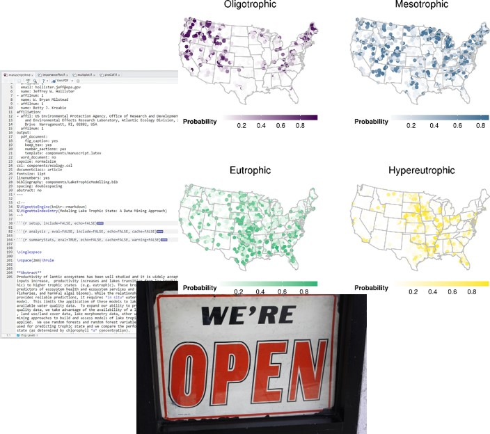

## R vs. Python

[figure not shown]

## R vs. & Python

[figure not shown]

## R and EPA

- Large and active community
- January 2019 ~900 installations at EPA (HQ offices only)
- [R Users Group](https://teams.microsoft.com/l/channel/19%3aa6272ef8a55c404ea56fa19145076a3d%40thread.skype/R%2520User%2520Group?groupId=93022b12-6005-468e-a542-501d13b4caa8&tenantId=88b378b3-6748-4867-acf9-76aacbeca6a7)
  - Teams channel in the Data Science team
  - Sharepoint (legacy)
  - Monthly meetings
- Installation (for HQ Offices, regions are Ad hoc)
  - R
  - RStudio
  - Rtools (required build tools for Windows)

## RStudio

- Integrated Development Environment
- Also a company that supports the R community
- RStudio 1-minute Demo

## Base R

## Extending Base R: Packages

## What can you do with R?

## Statistics

## Geospatial/GIS

## Documents

## Web applications

## Learn More

- #rstats